# 09 - Combining Graphs

econ 490

r

visualization

ggplot

combining graphs

This notebook explains how to combine graphs.

Author

Marina Adshade, Paul Corcuera, Giulia Lo Forte, Jane Platt

Published

29 May 2024

## Prerequisites

1. Load data and packages.
2. Create variables and objects.
3. Have some familiarity with the syntax of commands to create basic graphs.

## Learning Outcomes

1. Identify best practices for data visualization.
2. Feel comfortable with combining graphs using facets in `ggplot2`.

## 9.0 Intro

```r
# Clear the memory from any pre-existing objects
rm(list=ls())

# Load packages
library(tidyverse)
library(magrittr)
library(ggplot2)
library(haven)
library(tidyverse)

# Import dataset
fake_data <- read_dta("../econ490-r/fake_data.dta")
```

In this module, we will work on two examples. The first example covers combining two graphs with the same schema, while the second covers combining two graphs with different schemas. It will soon be very clear what we mean by *schema*.

## 9.1 Example 1

For this example, we want to generate two graphs with the same schema (they are the same type of graph and use the same variables as their x and y axis). For example, let’s say we want to see the evolution of average earnings over time for treated and untreated workers in two different regions. Instead of having four lines in one graph, we would like to separate the two regions in two different panels of the same graph.

Let’s do this step by step. We start by creating the data: we want a data frame with average earnings by year and treatment status for the first two regions. We use `group_by`, as seen in [Module 6](https://comet.arts.ubc.ca/docs/Research/econ490-r/06_Within_Group.html).

```r
figure1_data <- fake_data %>%
        mutate(log_earnings = log(earnings)) %>% # take log of earnings
        group_by(year, region, treated) %>%      # group by time, treatment status, and region
        summarise(mean_earnings = mean(log_earnings)) %>% # take average by group
        filter(region==1|region==2) %>%          # keep only first two regions
        mutate(treatment = case_when(treated == 1 ~ 'Treated', treated == 0 ~ 'Untreated')) # create a character variable for treatment
```

[output not shown]

Once we have created our data, we proceed with the same steps we have used in section 8.2.2 of [Module 8](https://comet.arts.ubc.ca/docs/Research/econ490-r/08_ggplot_graphs.html) to create a line plot with one line for each treatment status (*treated* and *untreated*).

In this case, we need to add a crucial component: `facet_grid`. This allows to split up our data by one or two variables that vary on the horizontal and/or vertical direction. The syntax is `facet_grid(vertical ~ horizontal)`.

In the code below, we split vertically our data for the two regions, by adding `facet_grid(region ~ .)` to our code.

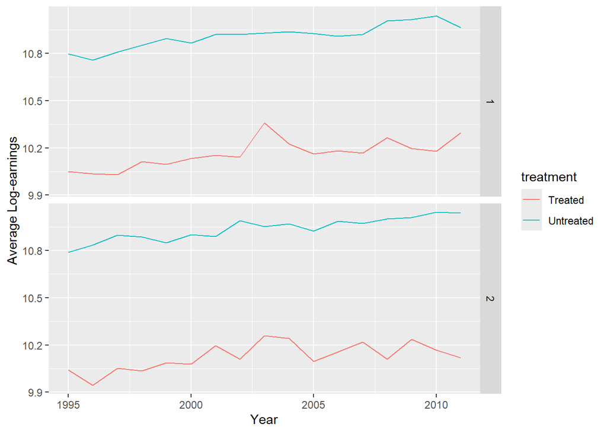

```r
# Specify data and axis
figure1 <- ggplot(data = figure1_data, # referencing the data we want to use
                 aes(
                     x = year,  # x is year
                     y = mean_earnings, # our y is avg logearnings
                     group=treatment, # each line is data for one value of treatment
                     color=treatment # each value of treatment as one color
                 ))

# Tell R the graph will be a line graph
figure1 <- figure1 + geom_line()

# Add labels
figure1 <- figure1 + labs(x = "Year", y = "Average Log-earnings")

# "split" vertically graph by region
figure1 + facet_grid(region ~ .)
```

Notice that now our graph is made of two panels whose titles are the names of the regions. However, we do not know what region 1 and region 2 mean. We can add a character variable to our data, named *region_name*, and split horizontally the graph into the two names stored in *region_name*.

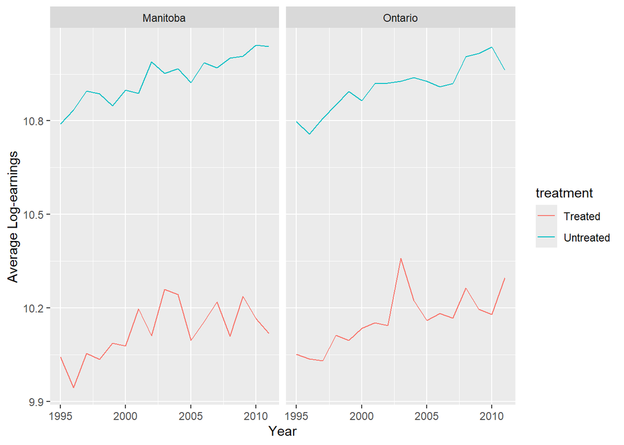

```r
# Add names to regions
figure1_data <- figure1_data %>%
                mutate(region_name = case_when(region == 1 ~ 'Ontario', region == 2 ~ 'Manitoba'))

# Specify data and axis
figure1 <- ggplot(data = figure1_data, # referencing the data we want to use
                 aes(
                     x = year,  # x is year
                     y = mean_earnings, # our y is avg logearnings
                     group=treatment, # each line is data for one value of treatment
                     color=treatment # each value of treatment as one color
                 ))

# Tell R the graph will be a line graph
figure1 <- figure1 + geom_line()

# Add labels
figure1 <- figure1 + labs(x = "Year", y = "Average Log-earnings")

# Split horizontally and use labels
figure1 + facet_grid(. ~ region_name)
```

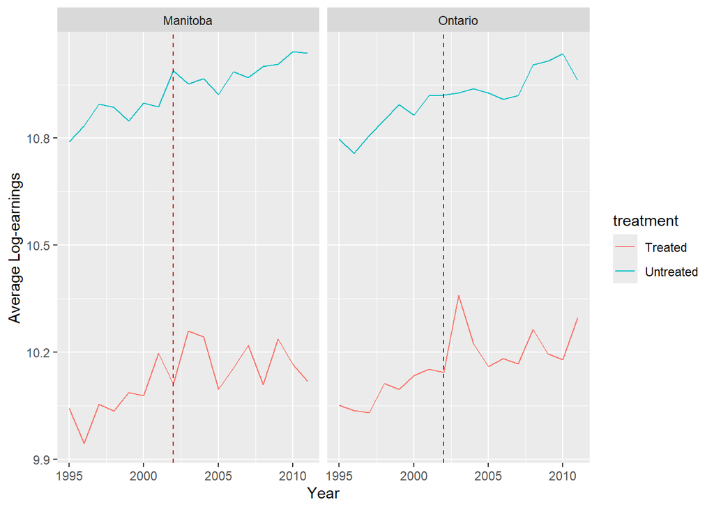

```r
# Add dashed red vertical line
figure1 <- figure1 + geom_vline(aes(xintercept=2002), color="#bb0000", linetype="dashed")

# Split vertically by region_name
figure1 + facet_grid(. ~ region_name)
```

## 9.2 Example 2

As we have seen in [Module 8](https://comet.arts.ubc.ca/docs/Research/econ490-r/08_ggplot_graphs.html), we usually use histograms to represent density distributions and we can use a scatterplot or a line plot for the graph of earnings over time.

We will now see how to use `grid.arrange` to put multiple graphs on one page. The `grid.arrange` function is stored in the library *gridExtra*, which we need to install. We do so below.

```r
# Install and laod
#install.packages("gridExtra")
library(gridExtra)
```

Let’s first create the two plots separately and then combine them together.

Start with the histogram: use `geom_histogram` to create a histogram for the density of log-earnings and store it into the object *plot1*. You can find a detailed explanation in section 8.2.3 of [Module 8](https://comet.arts.ubc.ca/docs/Research/econ490-r/08_ggplot_graphs.html).

```r
# Add log earnings to dataset
fake_data <- fake_data %>% mutate(log_earnings = log(earnings))

# Plot 1: histogram
plot1 <- ggplot(data = fake_data, aes(x = log_earnings)) + geom_histogram()
```

Then, create a line graph for the average log-earning by year using `geom_line` and store it into the object *plot2*. You can find a detailed explanation in section 8.2.2 of [Module 8](https://comet.arts.ubc.ca/docs/econ_490/econ490-r/08_ggplot_graphs.html).

```r
# Create a dataframe with the average wage by year
plot2_data <- fake_data %>%
              group_by(year) %>%
              summarise(mean_earnings = mean(log_earnings))

# Plot 2: line graph
plot2 <- ggplot(data = plot2_data, aes(x = year, y = mean_earnings)) + geom_line()
```

Now combine the objects *plot1* and *plot2* into one single page using the function `grid.arrange`. Notice that we can specify how many numbers of columns or rows we want with `ncol` or `nrow`, respectively.

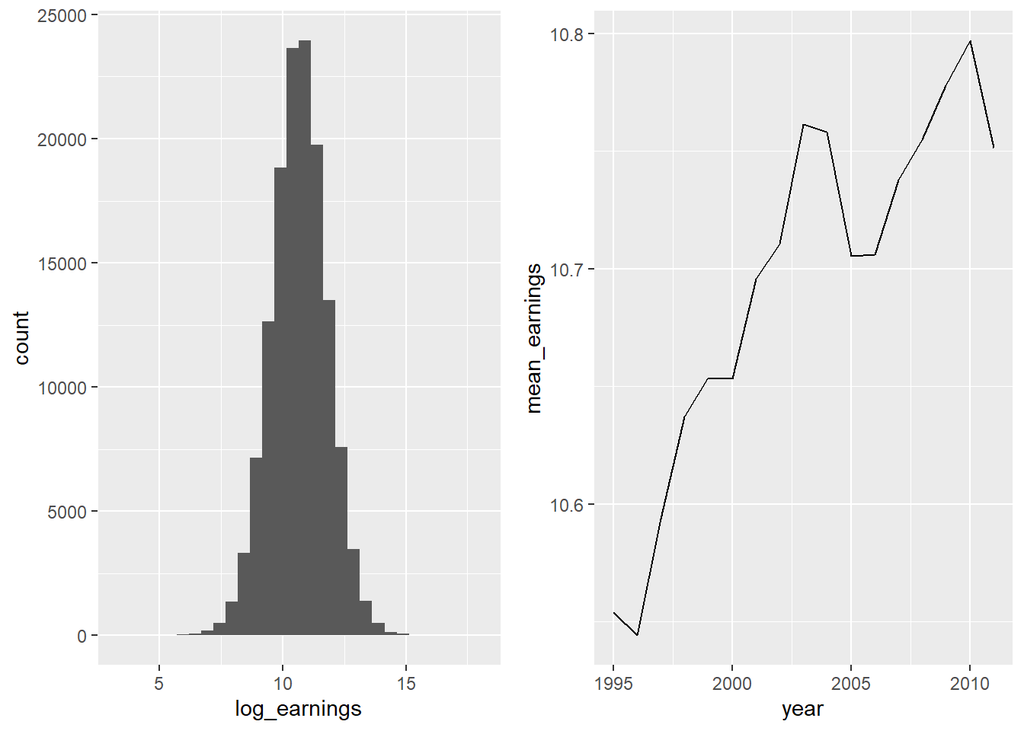

```r
grid.arrange(plot1, plot2, nrow=1)
```

## 9.4 Wrap-up Table

[output not shown]